# qc_test

Matthew Gregory

Thursday, September 17, 2015

[output not shown]

# Problem

Scientists should spend more time conducting experiments and less time repeating the same analyses with identical documentation.

## The solution

This is an R Markdown document that will demonstrate the utility of this style of reactive documentation for quality control at Oxitec.

## The data

Routine quality control experiments are designed to be consistent, facilitating comparison between, statistics through time. A tidy dataframe should be used to store the data facilitating automation.  
The data for an on/off tet experiment might look like this:

```
##   dose male female
## 1  0.0   45      1
## 2  0.0   42      2
## 3  0.0   43      3
## 4  0.0   48      1
## 5  0.0   49      0
## 6  0.2   46      1
```

We can look at the data and check it has been entered correctly. We can let the scientist apply a manual check or automate the process to confirm the data does not look suspicious.

```r
summary(mydata)
```

```
##       dose             male          female
##  Min.   :  0.00   Min.   :42.0   Min.   : 0.00
##  1st Qu.:  0.15   1st Qu.:44.0   1st Qu.: 1.00
##  Median :  5.10   Median :45.0   Median :21.50
##  Mean   : 27.55   Mean   :45.7   Mean   :23.05
##  3rd Qu.: 32.50   3rd Qu.:48.0   3rd Qu.:45.25
##  Max.   :100.00   Max.   :49.0   Max.   :49.00
```

```r
FemFract <- aggregate(female/male~dose, data=mydata, FUN=mean)
colnames(FemFract)[1] <- "Dose_ug"
colnames(FemFract)[2] <- "FemRatio"
```

We can print it to check it looks OK.

```r
FemFract
```

```
##   Dose_ug   FemRatio
## 1     0.0 0.03208841
## 2     0.2 0.04464909
## 3    10.0 0.91421563
## 4   100.0 1.03168910
```

Now for the analysis, notice how reproducible this is, we can set `echo = TRUE`. This is important for the `fct` argument in the `drm` function.

```r
#ANALYSIS
FitDRC <- drm(FemRatio ~ Dose_ug, data = FemFract, fct = LL.2())
LD50 <- ED(FitDRC,c(50),interval="delta")
```

```
##
## Estimated effective doses
## (Delta method-based confidence interval(s))
##
##      Estimate Std. Error    Lower  Upper
## 1:50  1.81750    0.57495 -0.65632 4.2913
```

We are interested in the LD50 and standard error.  
We can produce an informatic graphic to summarise.

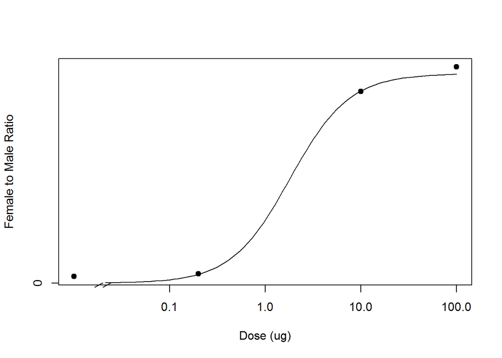